# Exploratory Data Analysis of White Wine Quality Dataset by Swaranika

Now we will move onto our next analysis - chlorides, alcohol and residual sugar:

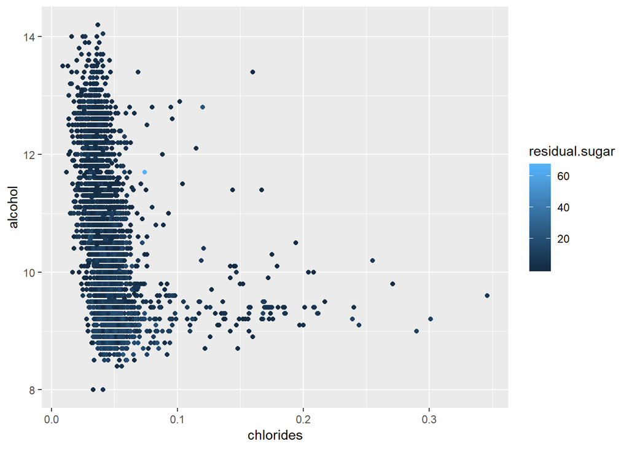

To get more useful analysis, we will ignore some outler in residual sugar and replot using the previously calculated res_sugar_iqr

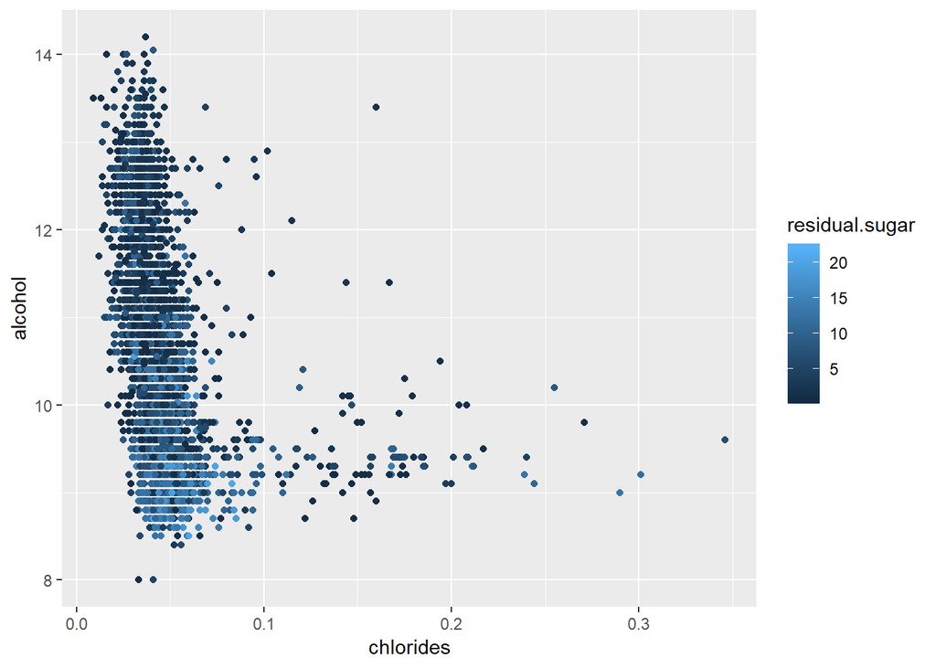

The above plot has surely improved the gradient from the first one and we can see that the white wines with higher amounts of residual sugar tend to have lower alcohol content. As we have not observed any distinct trend for the larger chloride values, next we are going to remove the chloride outliers.

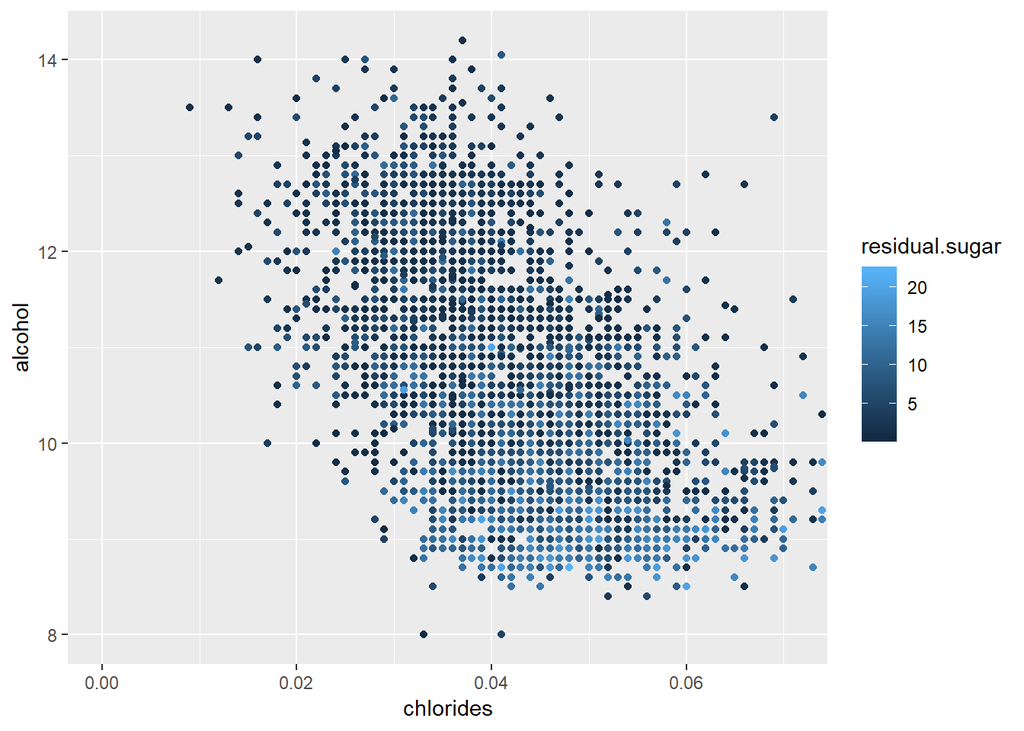

In this plot, we can observe that by removing the outliers , white wine with higher alcohol content tends to have smaller amounts of chlorides and residual sugar.To understand the outliers, we can facet this by the wine quality

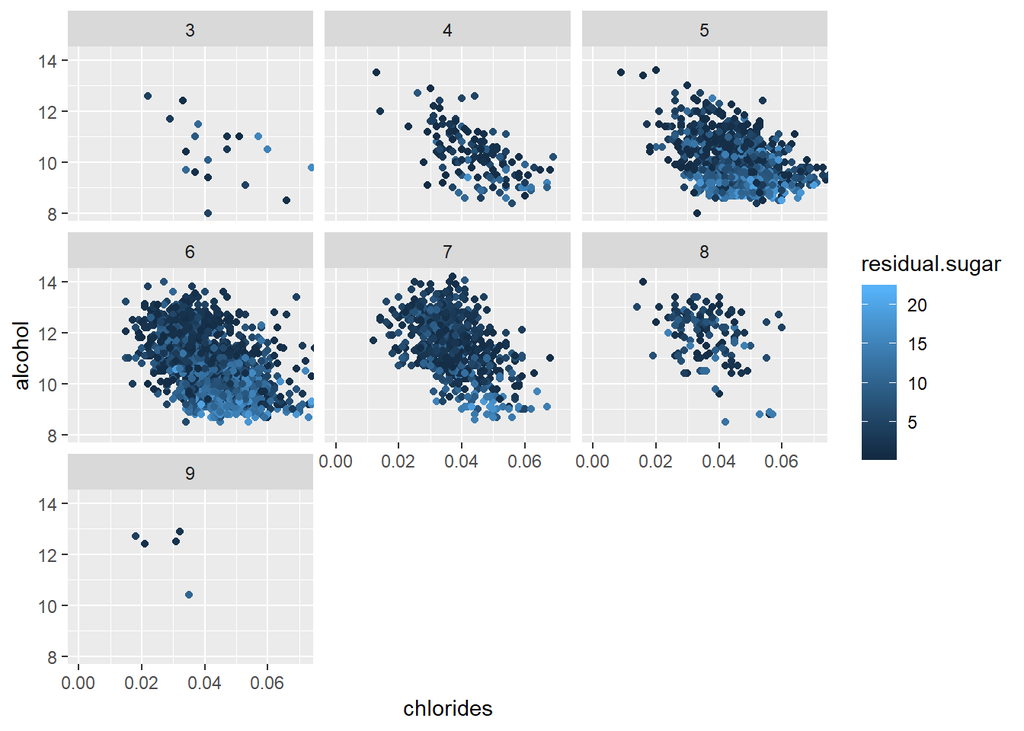

This plot suggests that as the quality of the white wine in our sample increases, the ones with higher concentration tend to have higher alcohol content and smaller amounts of chlorides and residual sugar. Next we can observe the Lower alcohol contents and their chlorides content facet by the wine quality

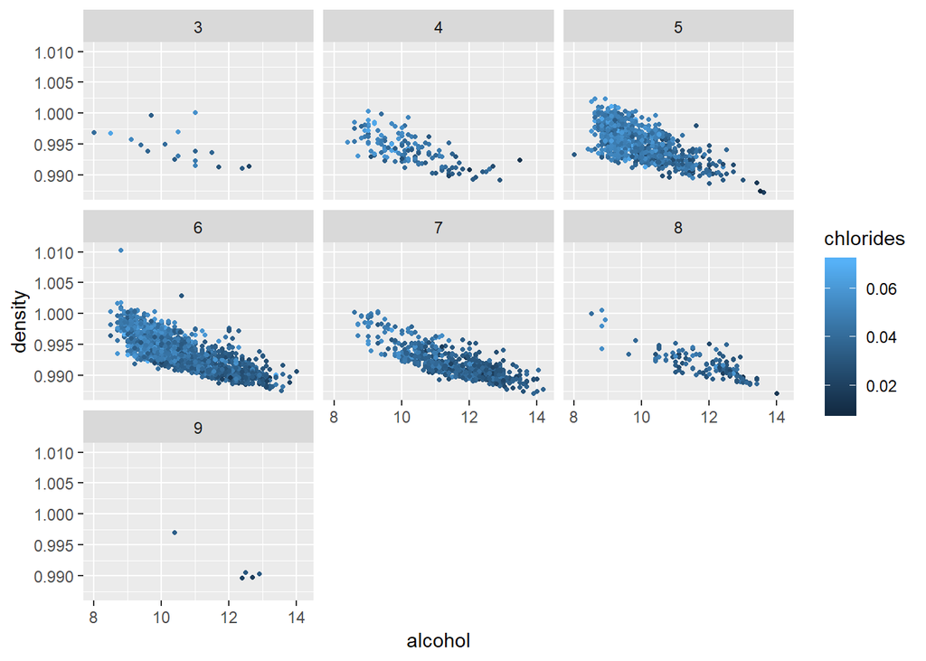

The plots show a distinct trend - higher quality wines tended to have higher amounts of alcohol and lower values for density. We can see that the low quality wines have more chlorides than high quality wines.

Now we will move on to considering residual sugar with high density wines in trems of quality.

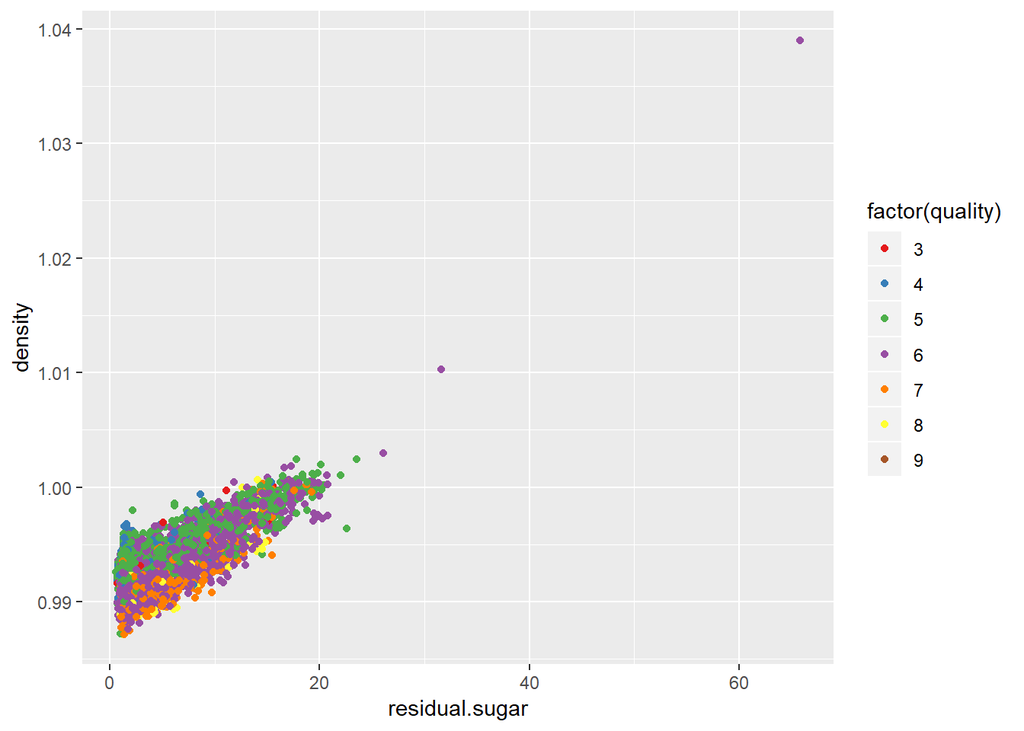

Digging deep into this plot by subsetting the white wine quality(same as previous plots, ignoring the wine with quality value =6)

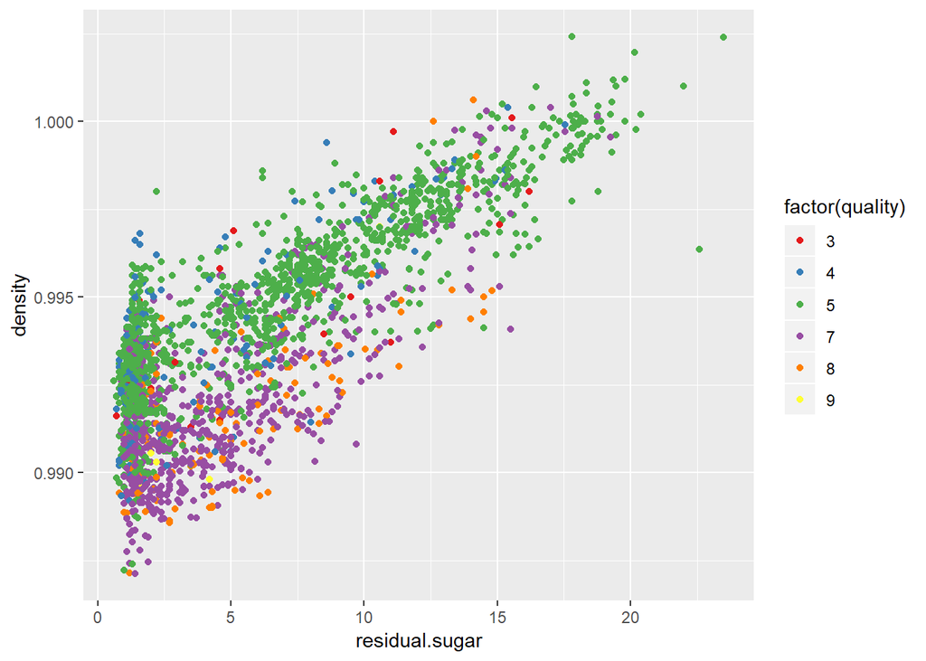

This diagram definitely depicts a trend among these three variables.The variation in density for fixed values of residual sugar ls likely to be happening because of the varying qualities in the wine.To get more from this trend, we can remove the outliers as we have done previously as well and plot again.

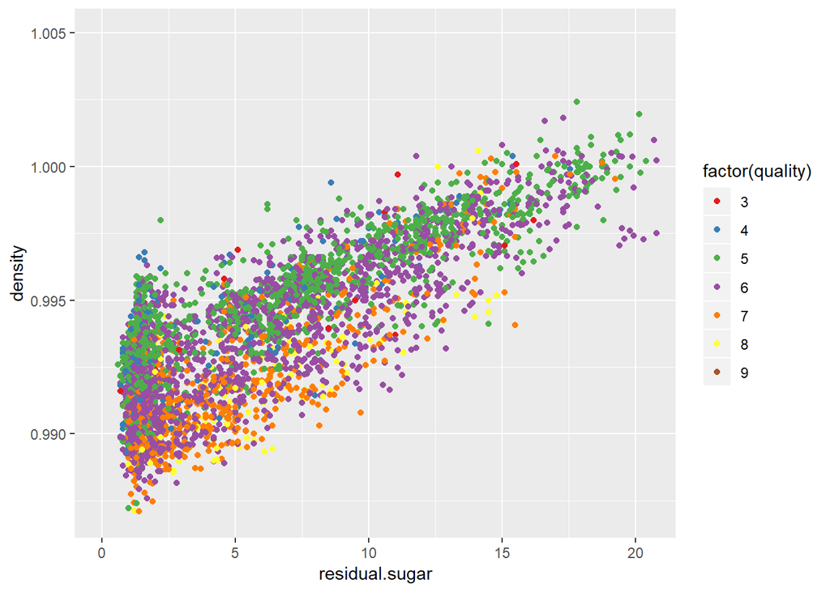

The gradient of this graph is prominent.This Density versus residual sugar plot is looks like triangle with base is along density axis.The upper arm of this triangle has a higher y-intercept which is desnity and there are a handful number of lower quality wines in that section. The lower arm of the triangle has a lower y-intercept -density and the higher quality winesa are visible in that section.But the trend appers to be less clear when wines have more than 10 g/L of residual sugar.

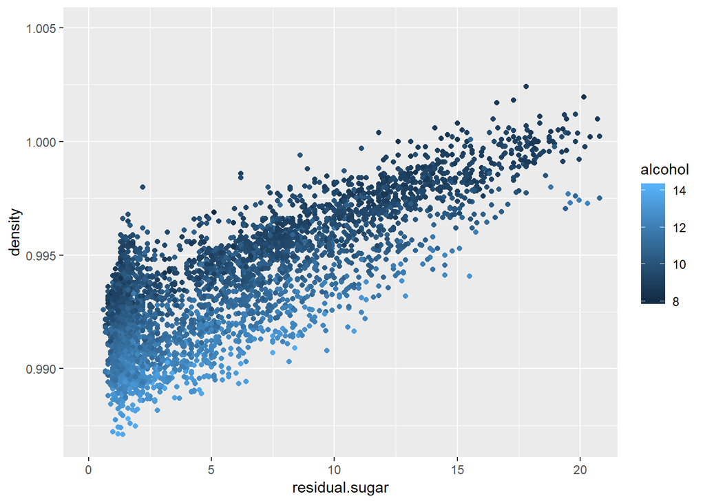

This plot actually backs up the summary we have observed from the previous plots - the greater the residual sugar, the higher the density and the lower the alcohol content. But for the lower values of residual sugar, there is greater variation in the density because of the differing amounts of alcohol. We can facet this plot by quality .

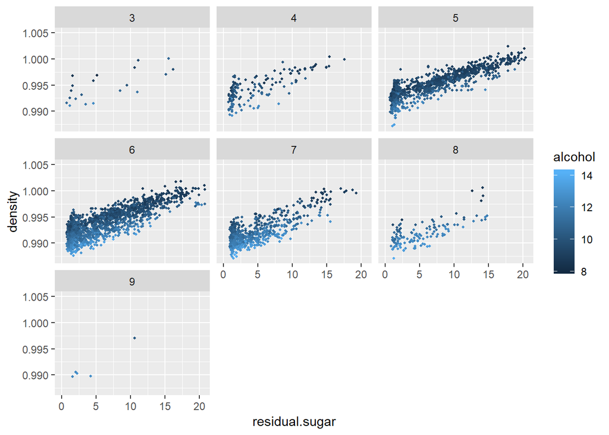

Now we have clear trends that the ower quality wines mostly have lower alcohol content and the higher quality wines have higher concentration of wines with higher alcohol content.

# Multivariate Analysis

### Talk about some of the relationships you observed in this part of the . Were there features that strengthened each other in terms of at your feature(s) of interest?

From the multivarite analysis, we have noticed some interesting relationship in our white wine test dataset.The trend of desnsity vs residual sugar is clearly depicted with the color of alcohol.Wines with higher amounts of residual sugar have lower alcohol content.In case of wines with lower amounts of residual sugar , there is density variation visble in presence of alcohol color.Th wine with more alcohol has the lower density. Finally this plot faceted by the wine quality depicts that the higher quality wines are tending have higher alcohol content and lower densities. From all the plots, I can see that the density and residual sugar has the strongest relationship and while they are colored by quality , the relationship becomes more visible.Wines having lower amounts of residual sugar are having greater variation in density, the lower density wines are better quality than the higher density wines. Also we have observed that alcohol is positively correlated with quality,chlorides negatively correlated with both alcohol and quality. As the quality of white wine has increased through the facets, we observe that larger concentration of wines with higher alcohol content have lower amounts of chlorides and residual sugar.

### Were there any interesting or surprising interactions between features?

one of the interesting/surprising interaction I have noticed is the correlation between alcohol, and chlorides. The negative correlation of alcohol and chlorides is surprising here as I was not able to get any proper reasoning behind this. Also interaction between alcohol and residual sugar and the interaction between alcohol and chlorides are interesting and surprising. Maybe people who know about the wine and its detail will find it natural so domain knowledge definitely will help in the understanding this relationship better.

# Final Plots and Summary

### Plot One

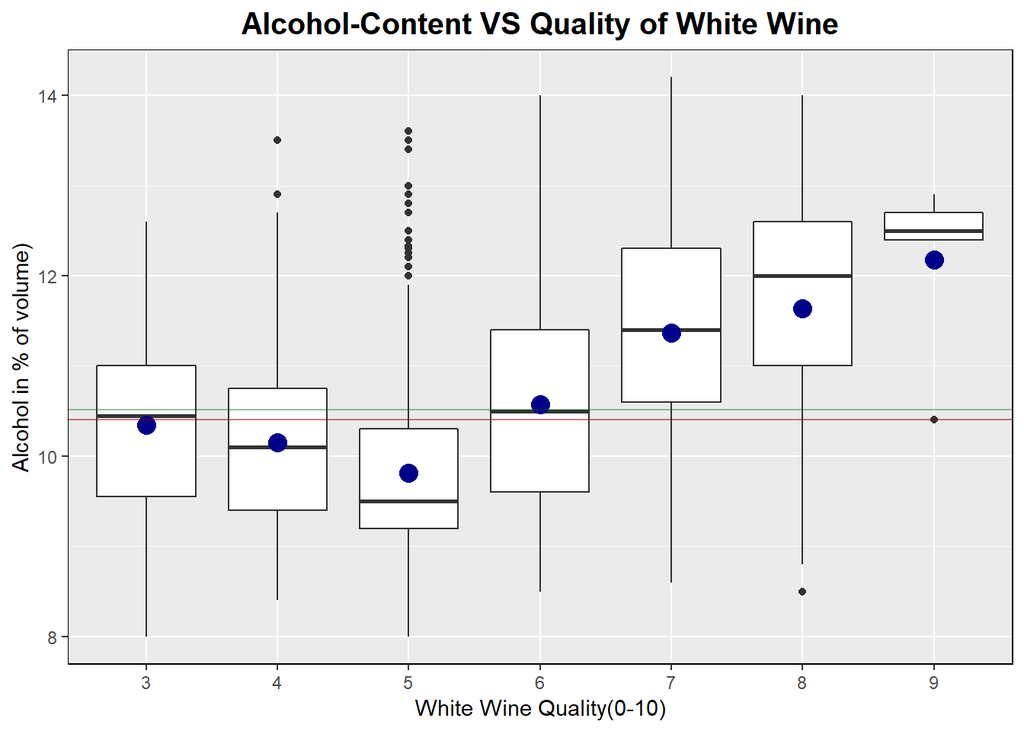

### Description One

This plot depicts the distribution of alcohol contebt in the white wine with respect to the quality of the wine ( which are number between 0 to 10).Darkblue dots on each of the boxplot are mean alcohol content for each quality of wine. The horizontal green line on the plot is the mean alcohol content for the entire dataset-> 10.51. The red line on the plot is the median alcohol content for the test dayaset -> 10.4  
From the previous section of analyzing and plotting different wine quality predictors,we have noticed that the percentage of alcohol in the wine is the most important parameter for deciding on the quality of white wine (having a correlation coefficient of 0.44).The trend that the higher quality wines tend to have higher alcohol values is very prominent specially for wines with quality range from 5 to 9. The reason behind choosing the boxplot is because of the scale of white wine quality which is scaled between 0 to 10,The boxplot clearly depicts the scale of quality along with the spread of alcohol content.

### Plot Two

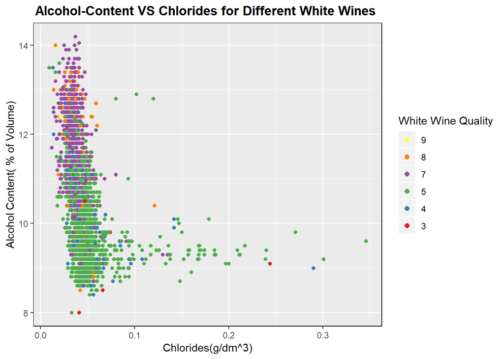

### Description Two

In the previous section, I have plotted different distributions of data and after condiering the situation to decrease the overplotting , the wine data with quality value = 6 have been removed and we have observed the trends more prominently. This plot depicts the relationship between alcohol and chlorides and also it shows how they both are related to quality. From the plots, we have noticed that the Wines with less alcohol and more chlorides are more of lower quality. Considering the fact that here we are plotting more than two attrbutes and trying to understand the relationship among them, I have prefered to choose this kind of plot rather than the boxplot before.

### Plot Three

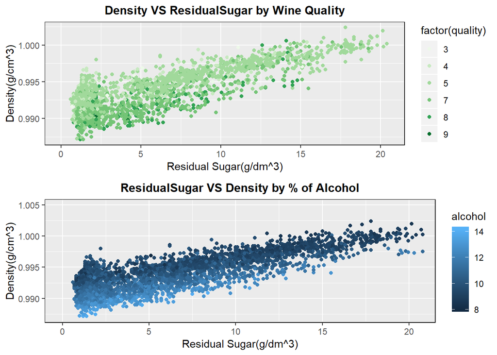

### Description Three

The first plot depicts the intereseting trend- the wines with less residual sugar and lower densities are usually better quality.The second plot depicts the strong relationship of desity , residual sugar quite with the alcohol colour gradiet which shows that the most density variations are because of the alcohol content.Selecting this grid kind of plot allows me to depict the relationship of desity and residual sugar with respect to alcohol and wine quality respectively and also one plot is becoming more meanigful in the presence of other.

# Reflection

Our test dataset has sample 0f 4898 number of white wines data. To begin with the exploratory data analysis , I have created different histograms to understand the different features and their distribution.Little bit exploration about the white wine and its quality predictors help me in getting the idea of how the features can be useful in the analysis. For the bivariate analysis, I have plotted few scatterplot matrix for the continuous variables and based on the strong corelations , in the next phase I have drilled down for the seperate variable to analyze thr strongest corelated variable with the wine quality.

In the following phase,I have selected the meanigful variables based on the correlation and then try to see how they are correlated with wine quality and also how they are corelated with each other along with their correlation with other variables in the dataset.In the phases of the plotting and analyzing , I have carefully ignore the variables with lno meaningful correlation.I have noticed that our dataset lacks of more spreaded quality values. Most of the wines are ‘NORMAL’ and hence it was difficult the clusterize. One major struggle while doing the exploratory analysis was going through all the variables and their impact on wine quality.Not only the number of variables in the dataset but also most of the variables are likely related.Also the fact that most of these variables can be related through chemical reactions in many possible combinations was overwhelming as well.Domain knowledge is somewhat ,I feel important in understanding the relationship among variables.The multivariate analysis proved to be the most challenging section for me. While evaluating more than two variables at once, there are countless possibilities for creating the visualization and there is a multitude of variable combinations to investigate.So what I have done here is if I have observed any interesting relationship in the bivariate analysis, I have further analyzed the same relationship using another variable in the mutivariate analysis.

In future, with more time on this dataset, I would love to analyze the differentiator for low alcohol wines and also can create new features as well.Next step will definitely be building of regression model where the ipact of the various variables on wine quality will be consistent with our exploratory data analysis.I can create a subset of our test dataset and explore all the variables again think I would have to subset the data and look into all of the variables again. Also if I can able to get more even-classed dataset with more low and high quality wines, then the trend will be visible better.Also the price of the wine will be intresting add-on for analysis. Overall,it was an important projectwork in terms of the efforts of applying reasoning and finding trends and conclusions on a new dataset with little domain knowledge. More exploring on different datasets will definitely help me in developing the analysis skills.